# ggplot2 Tips: Making Your Plots Report-Ready

Pharma Code Club: Data Visualization

Published

October 20, 2026

# Introduction

This document follows the slides from today’s session. It is meant as a **lookup guide**: each section shows one thing you can change in a ggplot, a short table of the most useful arguments, and a code chunk you can run and play with.

> **Tip:** Change one argument at a time and re-run the chunk. That is the fastest way to see what it does.

# 1 Setup

We only need the tidyverse (which includes ggplot2). All data is simulated below, so this document runs on its own. `theme_set(theme_classic(base_size = 14))` makes the classic theme with slightly larger text (14 pt) the default for all plots instead of the grey one (more on this in the section on global defaults).

```r
library(tidyverse)
theme_set(theme_classic(base_size = 14))

set.seed(5)
# Tablet weight vs. amount of active ingredient
tablet_dose <- tibble(weight_mg = rnorm(120, 505, 16),
                      dose_mg   = 250 + 0.5 * (weight_mg - 500) + rnorm(120, 0, 7))

set.seed(8)
# Same, but for three production batches (batch C has a lower content)
tablet_batches <- tibble(batch     = rep(c("A", "B", "C"), each = 30),
                         weight_mg = rnorm(90, rep(c(500, 505, 495), each = 30), 10),
                         dose_mg   = rep(c(0.50, 0.50, 0.47), each = 30) * weight_mg +
                                     rnorm(90, 0, 4))

set.seed(3)
# Substrate uptake by a transporter (Michaelis-Menten)
uptake <- expand_grid(conc_um = c(0, 5, 10, 25, 50, 100, 200, 400), replicate = 1:3) %>%
  mutate(rate = 120 * conc_um / (30 + conc_um) * rnorm(n(), 1, 0.07))
```

We store the basic plots as objects (`p`, `p_batch`, `p_mm`) and add to them in the sections below.

```r
p <- ggplot(tablet_dose, aes(x = weight_mg, y = dose_mg)) +
  geom_point()

p_batch <- ggplot(tablet_batches, aes(x = weight_mg, y = dose_mg, colour = batch)) +
  geom_point()

p_mm <- ggplot(uptake, aes(x = conc_um, y = rate)) +
  geom_point()
```

# 2 Linear fit: `geom_smooth()`

`geom_smooth(method = "lm")` fits and draws a straight line (a linear model).

| Argument | What it does |
| --- | --- |
| `method = "lm"` | straight line; without it you get a wiggly smooth curve (loess) |
| `se = FALSE` | removes the grey band (the 95% confidence interval of the line) |
| `fullrange = TRUE` | extends the line to the edges of the plot: **extrapolation**, mention it in the caption |
| `colour`, `linetype`, `linewidth` | the look of the line |
| `data = ...` | fit on a subset, e.g. without an outlier, while still showing all points |

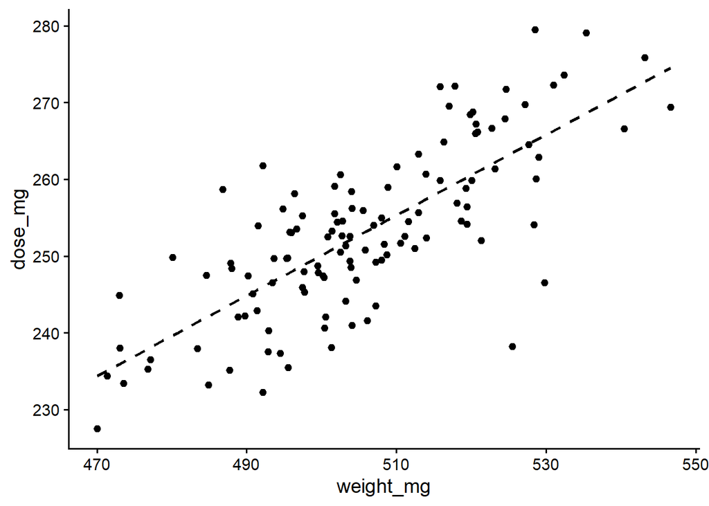

```r
p + geom_smooth(method = "lm", se = FALSE,
                colour = "black", linetype = "dashed", linewidth = 1)
```

**Line types:** `"solid"`, `"dashed"`, `"dotted"`, `"dotdash"`, `"longdash"`, `"twodash"`. The same `colour`, `linetype` and `linewidth` arguments work for all line geoms in this document.

# 3 Your own lines

| Function | What it draws |
| --- | --- |
| `geom_abline(intercept, slope)` | a straight line from a known intercept and slope; always spans the whole plot |
| `geom_function(fun = ...)` | any function of x, also nonlinear |

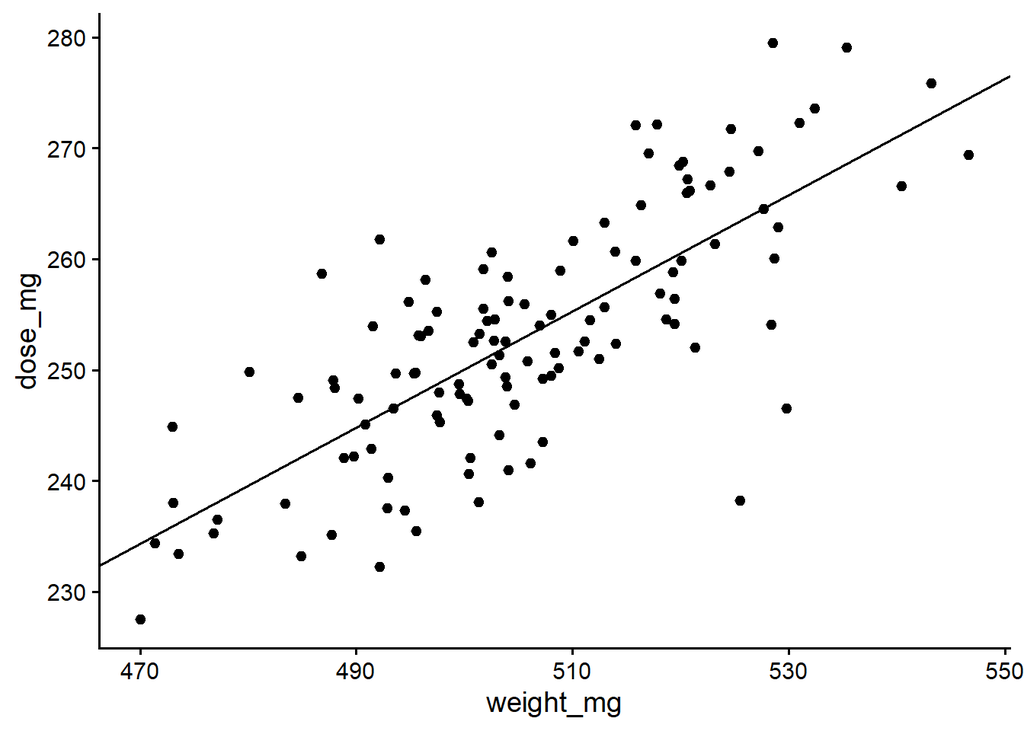

```r
fit <- lm(dose_mg ~ weight_mg, data = tablet_dose)

p + geom_abline(intercept = coef(fit)[1], slope = coef(fit)[2])
```

`geom_function()` does not use your data: it takes the x-range of the plot, calculates `fun(x)` at 101 points and draws a line through them. `\(x)` is short for `function(x)`; `x` is just a placeholder, not a column.

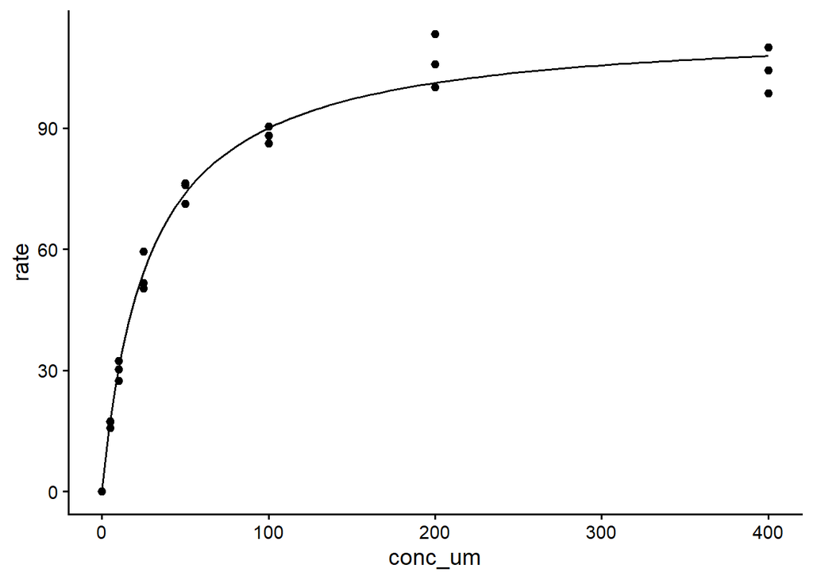

```r
mm_fit <- nls(rate ~ Vmax * conc_um / (Km + conc_um), data = uptake,
              start = list(Vmax = 100, Km = 20))
Vmax <- coef(mm_fit)["Vmax"]
Km   <- coef(mm_fit)["Km"]

p_mm + geom_function(fun = \(x) Vmax * x / (Km + x))
```

> **Tip:** `xlim = c(0, 200)` inside `geom_function()` draws only part of the curve, and `n = 500` makes it smoother.

# 4 Reference lines and text

| Function | What it does |
| --- | --- |
| `geom_hline(yintercept = ...)` | horizontal line at a fixed value |
| `geom_vline(xintercept = ...)` | vertical line at a fixed value |
| `annotate("text", x, y, label)` | one label at a position in axis units |
| `hjust = 0` / `1` | left / right-align the text at x |

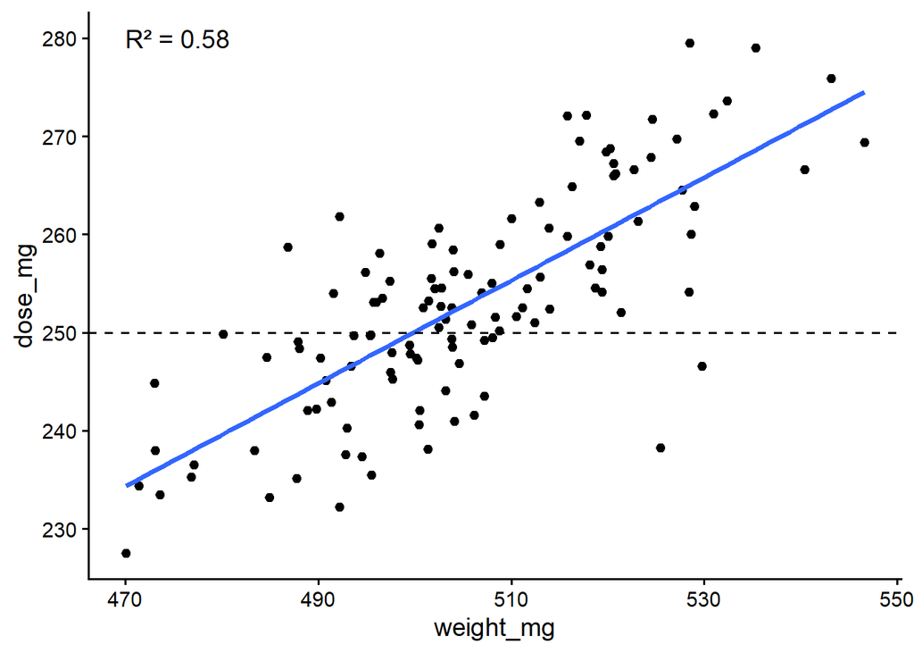

```r
r2 <- summary(fit)$r.squared

p + geom_smooth(method = "lm", se = FALSE) +
  geom_hline(yintercept = 250, linetype = "dashed") +
  annotate("text", x = 470, y = 280, hjust = 0,
           label = paste("R² =", round(r2, 2)))
```

# 5 Axes: `scale_x_continuous()` and `scale_y_continuous()`

| Argument | What it does |
| --- | --- |
| `limits = c(0, 200)` | range of the axis. **Data outside is removed** (see the warning “Removed n rows”) |
| `breaks = seq(0, 400, by = 50)` | where the tick marks are |
| `expand = c(0, 0)` | removes the air between data and axes |

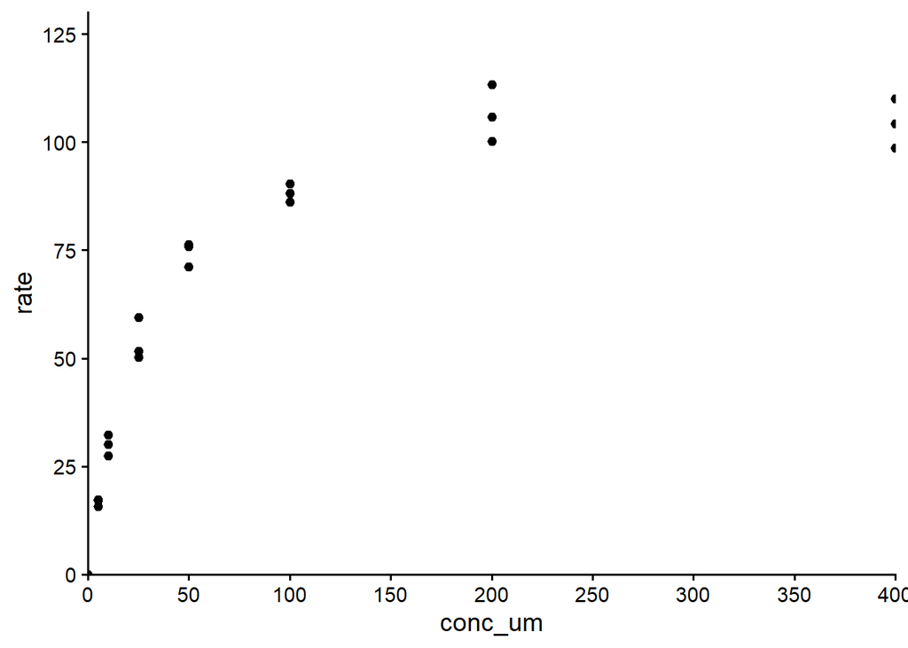

```r
p_mm +
  scale_x_continuous(limits = c(0, 400), breaks = seq(0, 400, by = 50),
                     expand = c(0, 0)) +
  scale_y_continuous(limits = c(0, 130), expand = c(0, 0))
```

> **Tip:** `expand = expansion(mult = c(0, 0.05))` controls each side: no air at the bottom, 5% at the top.

## 5.1 Log scale

`scale_x_log10()` / `scale_y_log10()` take the same arguments. `annotation_logticks()` adds small log ticks, so values are easier to read off. Log of 0 is not possible, so remove 0 values first.

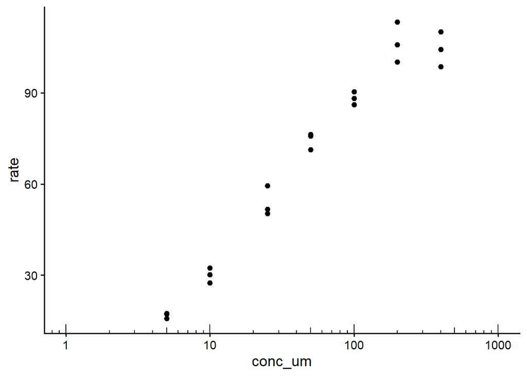

```r
uptake %>%
  filter(conc_um > 0) %>%
  ggplot(aes(x = conc_um, y = rate)) +
  geom_point() +
  scale_x_log10(breaks = c(1, 10, 100, 1000), limits = c(1, 1000)) +
  annotation_logticks(sides = "b")   # "b" = bottom, "l" = left
```

# 6 Zoom: `coord_cartesian()`

`coord_cartesian()` zooms **without removing data**, so calculations like a fitted line stay the same. It has fewer options than `scale_*()`: for breaks and labels you still need the scale.

| Argument | What it does |
| --- | --- |
| `xlim`, `ylim` | zoom range |
| `expand = FALSE` | no air around the data |
| `clip = "off"` | points on the edge are drawn in full |

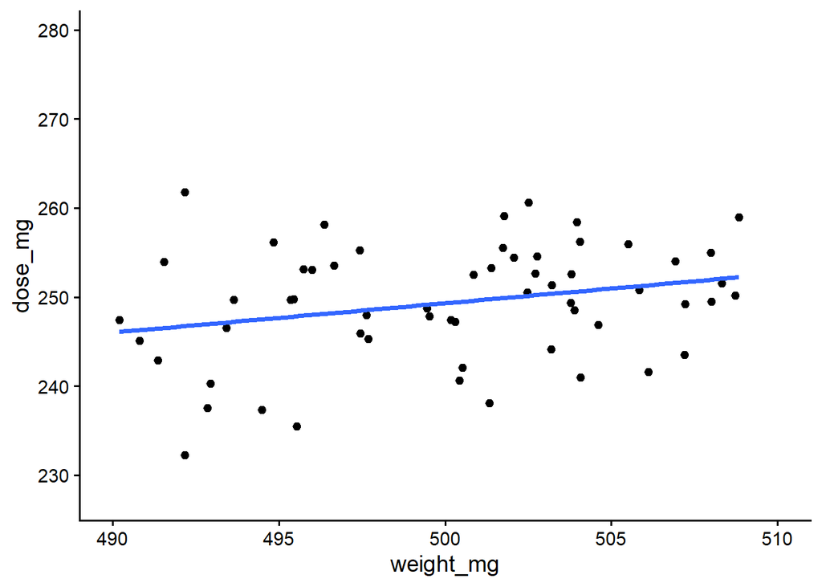

```r
p_fit <- p + geom_smooth(method = "lm", se = FALSE)

p_fit + scale_x_continuous(limits = c(490, 510))   # removes data: the line changes
```

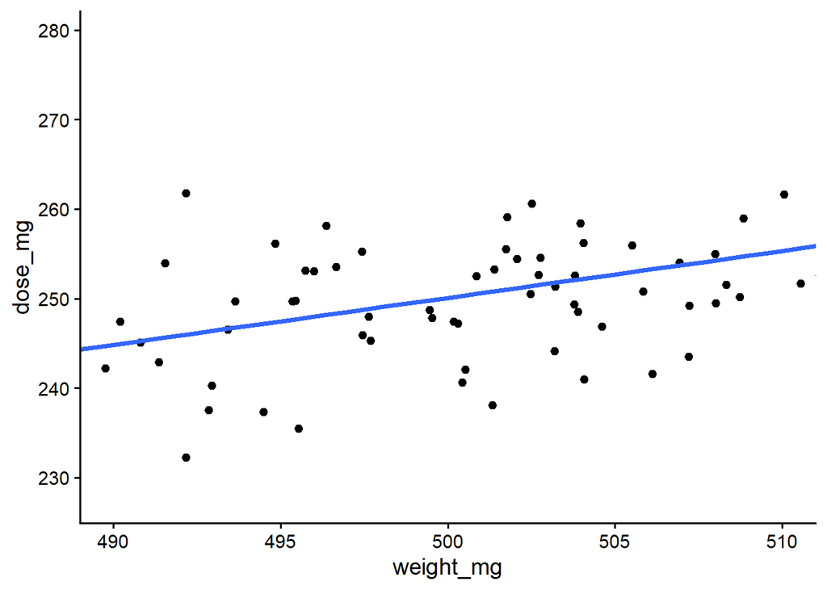

```r
p_fit + coord_cartesian(xlim = c(490, 510))         # zooms: the line stays the same
```

> **Note:** With `clip = "off"` and a zoom, data outside the limits is drawn over the axes. Only use it when the limits contain all your data.

# 7 Split groups: `facet_wrap()`

When colours alone get cluttered, give each group its own panel.

| Argument | What it does |
| --- | --- |
| `~ batch` | the variable to split by |
| `ncol`, `nrow` | layout of the panels |
| `scales = "free_y"` | each panel its own y-axis (harder to compare!) |

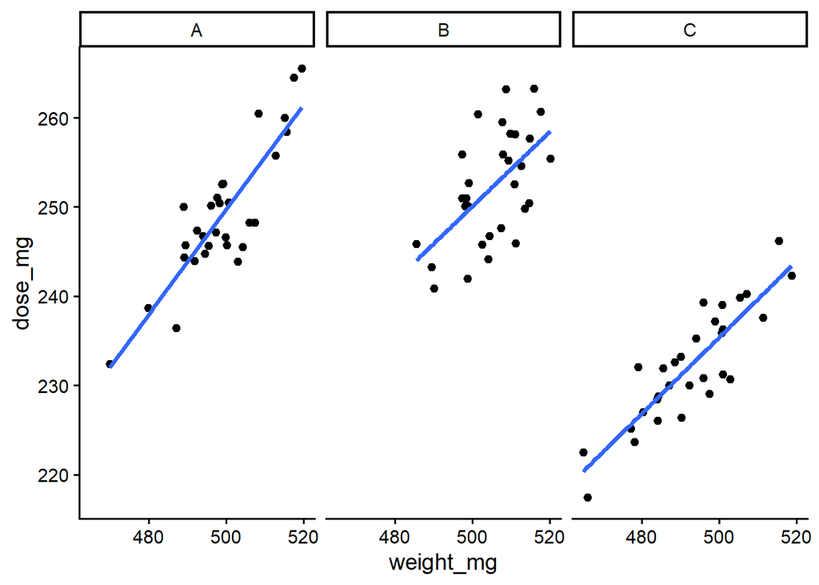

```r
ggplot(tablet_batches, aes(x = weight_mg, y = dose_mg)) +
  geom_point() +
  geom_smooth(method = "lm", se = FALSE) +
  facet_wrap(~ batch, ncol = 3)
```

# 8 Colours

Four ways to write the same colour:

| You write | Type |
| --- | --- |
| `"steelblue"` | name (`colors()` lists all 657) |
| `"#4682B4"` | hex code |
| `rgb(70, 130, 180, max = 255)` | RGB, 0 to 255 |
| `hsv(0.576, 0.611, 0.706)` | HSV, 0 to 1 |

**One colour for everything:** set it *outside* `aes()`.

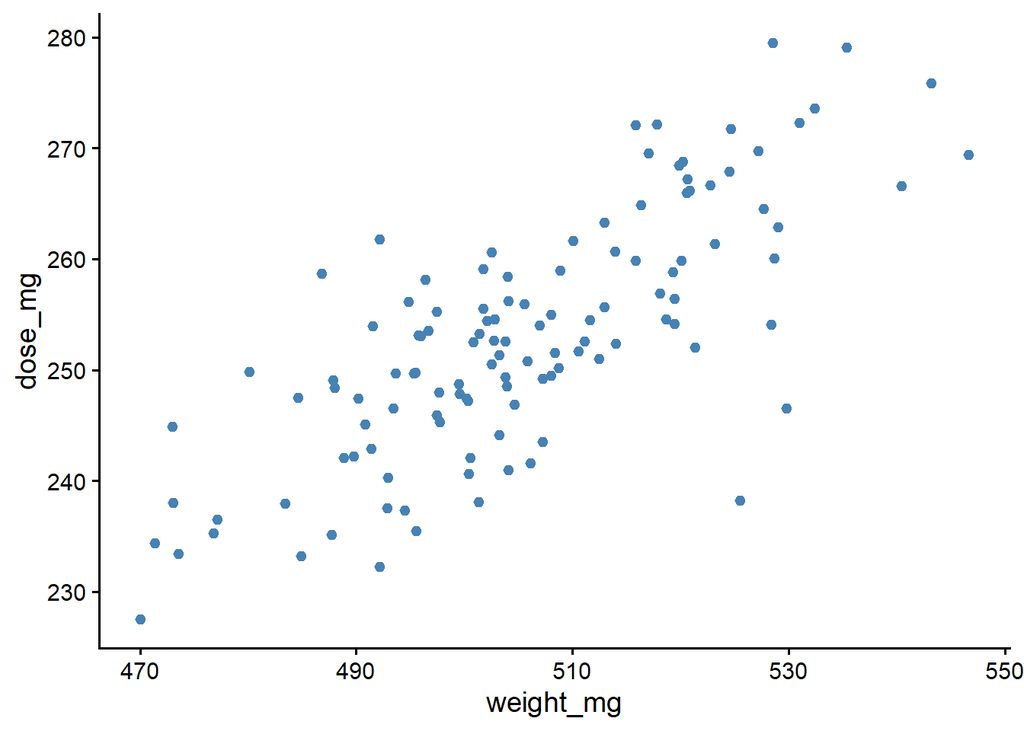

```r
p + geom_point(colour = "#4682B4")
```

**Your own palette for groups:** `scale_colour_manual()` (or `scale_fill_manual()` for bars and boxes). An unnamed vector is used in the order of the groups; a named vector gives each group a fixed colour in every plot.

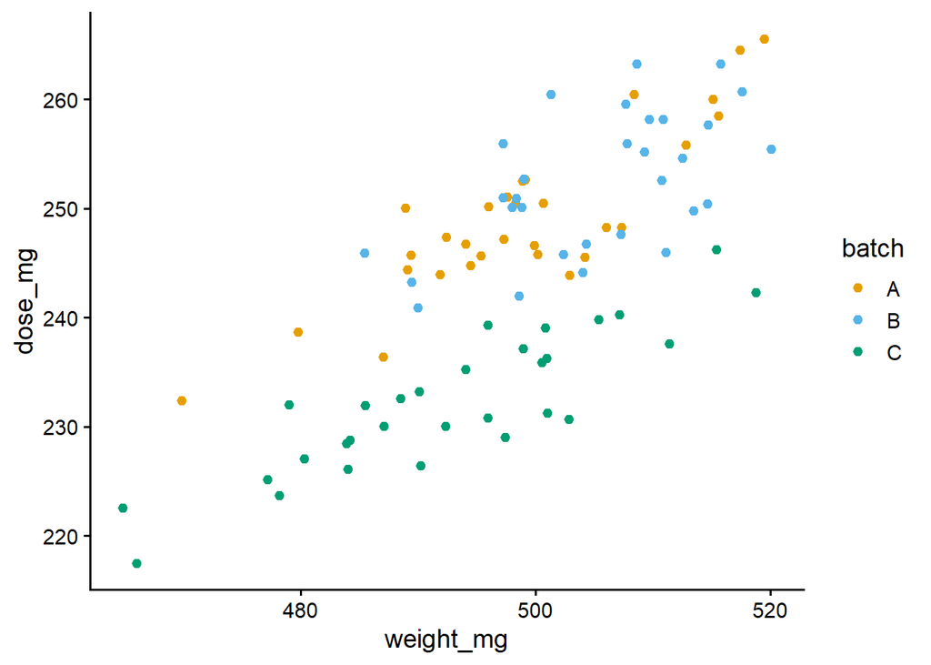

```r
my_cols <- c(A = "#E69F00", B = "#56B4E9", C = "#009E73")

p_batch + scale_colour_manual(values = my_cols)
```

# 9 Axis titles with units and symbols

`labs()` sets all titles. Simple symbols can be typed directly (`"Concentration (µM)"`). For sub- and superscripts use `expression()`, which is R code drawn as maths:

| You write | You get |
| --- | --- |
| `mu`, `Delta` | µ, Δ (Greek letters by name) |
| `C[max]` | C<sub>max</sub> (subscript) |
| `min^-1` | min<sup>-1</sup> (superscript) |
| `%.%` | · (multiplication dot) |
| `*`, `~` | join pieces without / with a space |
| `"text"` | text with spaces or brackets goes in quotes |

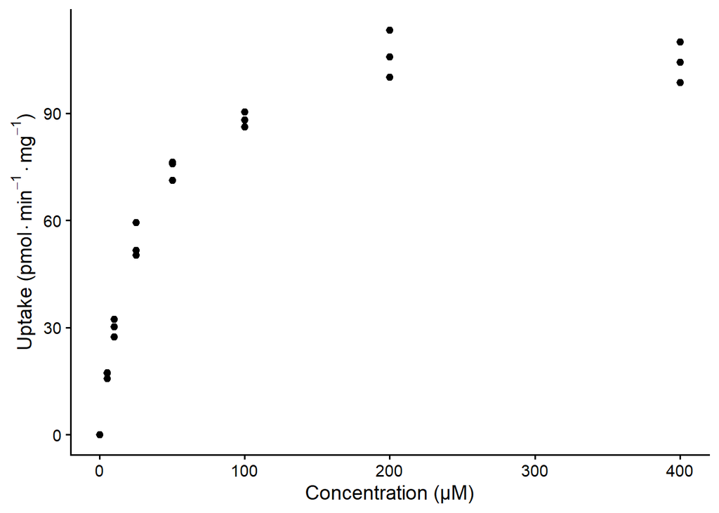

```r
p_mm + labs(
  x = "Concentration (µM)",
  y = expression("Uptake (pmol" %.% min^-1 %.% mg^-1 * ")"))
```

# 10 The legend

| Code | What it does |
| --- | --- |
| `labs(colour = "Batch")` | change the legend title (use `fill`, `shape`, … for those legends) |
| `labs(colour = NULL)` | no legend title |
| `theme(legend.position = "bottom")` | `"right"` (default), `"left"`, `"top"`, `"bottom"`, `"none"` |
| `theme(legend.position = "inside", legend.position.inside = c(0.15, 0.8))` | inside the plot; numbers from 0 to 1 (left to right, bottom to top) |

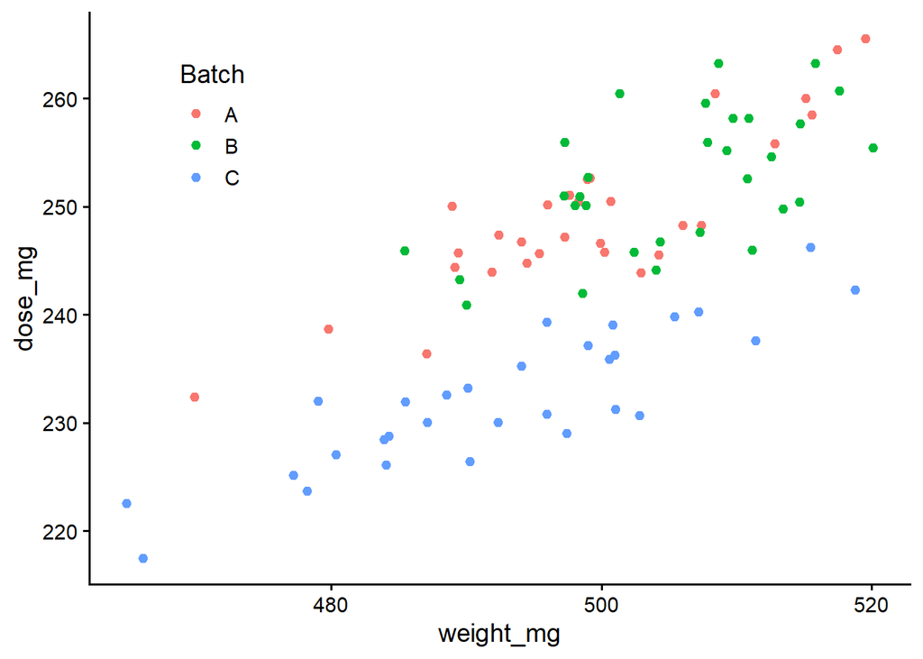

```r
p_batch +
  labs(colour = "Batch") +
  theme(legend.position = "inside",
        legend.position.inside = c(0.15, 0.8))
```

> **Note:** `"inside"` needs ggplot2 3.5 or newer. In older versions: `theme(legend.position = c(0.15, 0.8))`.

# 11 Themes

## 11.1 Built-in and package themes

All themes take `base_size`, the text size in points: `theme_classic(base_size = 14)`.

| Theme | Look |
| --- | --- |
| `theme_grey()` | default, grey panel |
| `theme_bw()` | white panel with a frame |
| `theme_classic()` | axis lines, no grid |
| `theme_minimal()` | grid only |
| `theme_prism()` (ggprism) | GraphPad Prism look |
| `theme_pubr()` (ggpubr) | publication style |
| `theme_few()`, `theme_economist()` (ggthemes) | clean / The Economist style |

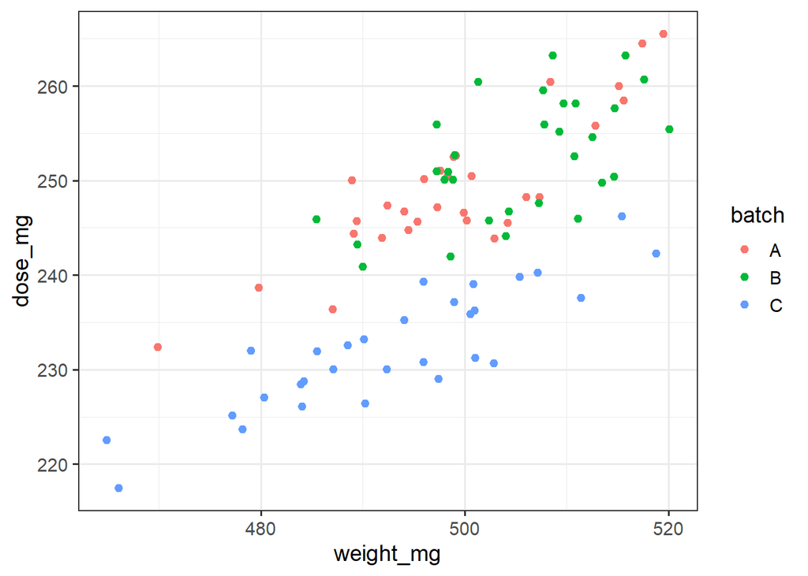

```r
p_batch + theme_bw(base_size = 14)
```

Package themes need the package: install it once, then load it with `library()`.

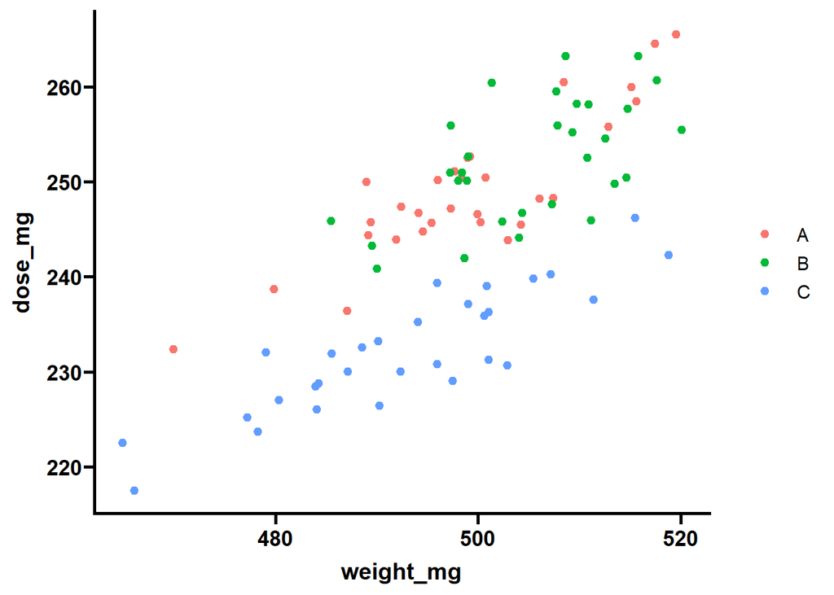

```r
# install.packages("ggprism")   # run once (remove the # first)
library(ggprism)
p_batch + theme_prism()
```

## 11.2 Change details with `theme()`

Every part of the plot has a name (the *element*), and a function says *how* to change it:

| Element | Function |
| --- | --- |
| `axis.title`, `axis.text` | `element_text(size, face, colour)` |
| `axis.line`, `panel.grid.major`, `panel.grid.minor` | `element_line(colour, linewidth)` |
| `panel.background`, `panel.border` | `element_rect(fill, colour)` |
| `legend.title`, `axis.ticks` | `element_blank()` removes it |

Add `.x` or `.y` to change one axis only, e.g. `panel.grid.major.y`. Put `theme()` **after** the base theme, otherwise the base theme overwrites your changes.

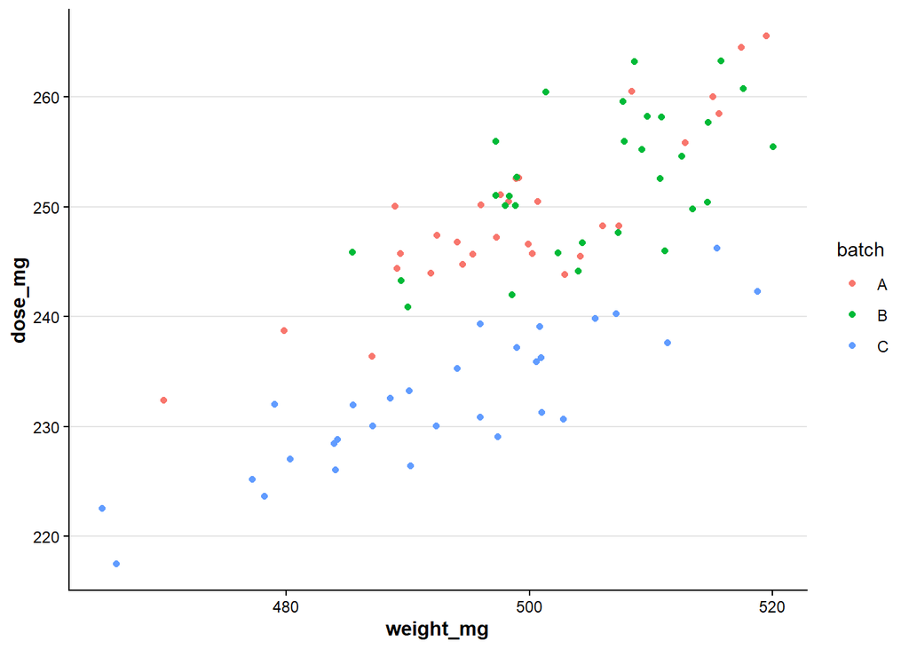

```r
p_batch +
  theme_classic() +
  theme(axis.title = element_text(face = "bold"),
        panel.grid.major.y = element_line(colour = "grey90"))
```

> **Tip:** Type `theme(` and press Tab in RStudio to see all elements.

## 11.3 Save your own theme

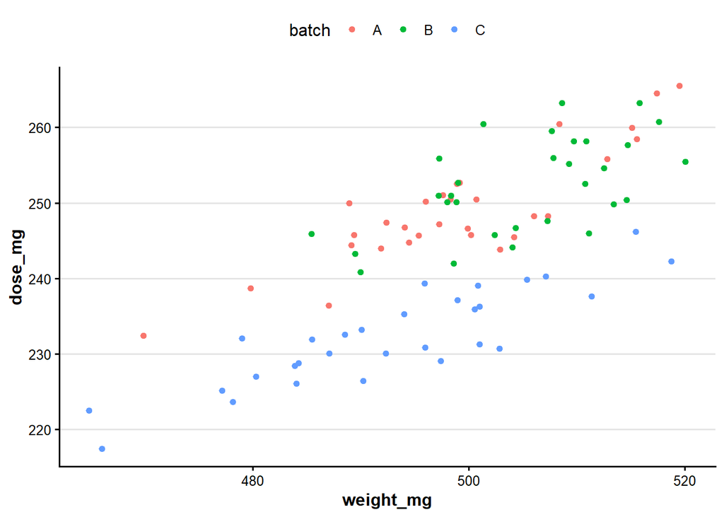

```r
theme_mine <- function(base_size = 12) {
  theme_classic(base_size = base_size) +
    theme(axis.title = element_text(face = "bold"),
          panel.grid.major.y = element_line(colour = "grey90"),
          legend.position = "top")
}

p_batch + theme_mine()
```

# 12 Set it once: global defaults

Put this at the top of a script or Quarto document, and every plot after it uses these settings.

| Code | Sets the default for |
| --- | --- |
| `theme_set(theme_mine())` | theme |
| `options(ggplot2.discrete.colour = ..., ggplot2.discrete.fill = ...)` | colours for groups (use an unnamed vector) |
| `update_geom_defaults("point", list(size = 2.5))` | the look of one geom |
| redefine `scale_y_continuous` (below) | scale settings, e.g. no air |

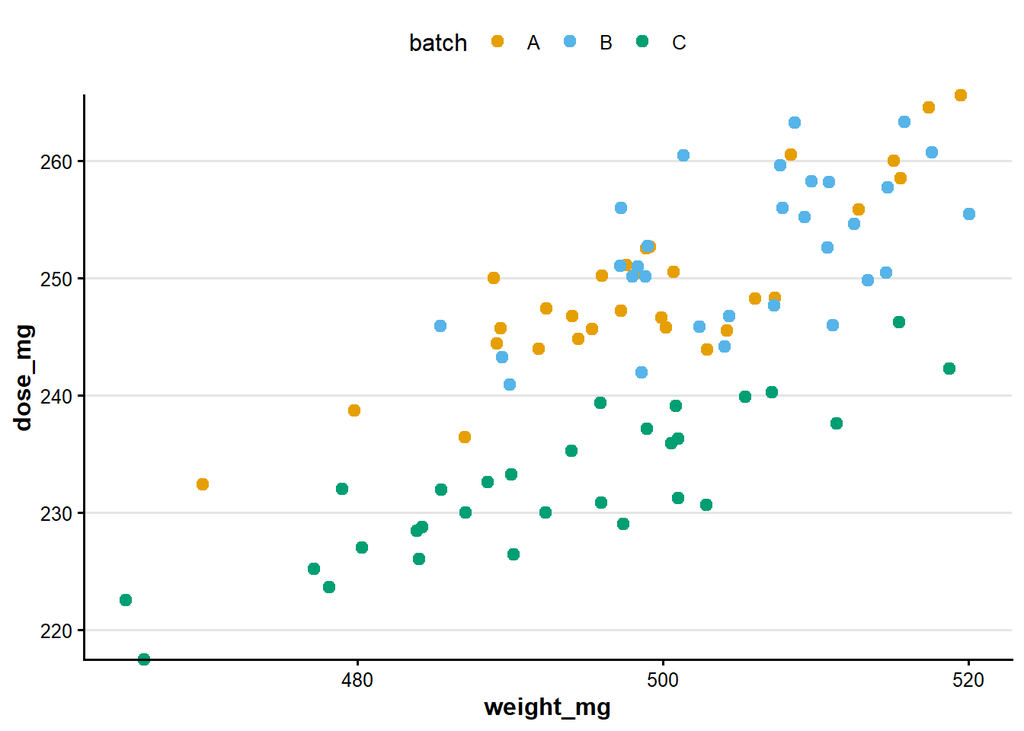

```r
theme_set(theme_mine())
options(ggplot2.discrete.colour = c("#E69F00", "#56B4E9", "#009E73"))
update_geom_defaults("point", list(size = 2.5))
scale_y_continuous <- function(..., expand = c(0, 0)) {
  ggplot2::scale_y_continuous(..., expand = expand)
}

ggplot(tablet_batches, aes(x = weight_mg, y = dose_mg, colour = batch)) +
  geom_point() +
  coord_cartesian(clip ="off")
```

`ggplot2::` in the last part is needed: it calls the original function, not the new one we are defining. To undo the defaults again (back to the classic theme from the setup):

```r
theme_set(theme_classic(base_size = 14))
options(ggplot2.discrete.colour = NULL)
update_geom_defaults("point", list(size = 1.5))
rm(scale_y_continuous)
```

# 13 Size and saving

## 13.1 Readable text

A plot that looks fine in RStudio can end up with tiny text in a report. Decide the final size first: the text width of an A4 page is about 16 cm (6.3 inches). Then set `base_size` to roughly the font size of your report (10 to 12 pt).

## 13.2 In Quarto

| Chunk option | What it does |
| --- | --- |
| `#\| fig-width: 6.3` | width of the canvas R draws on, in inches |
| `#\| fig-height: 4` | height in inches |
| `#\| out-width: "80%"` | how big the finished picture is shown; text shrinks or grows with it |

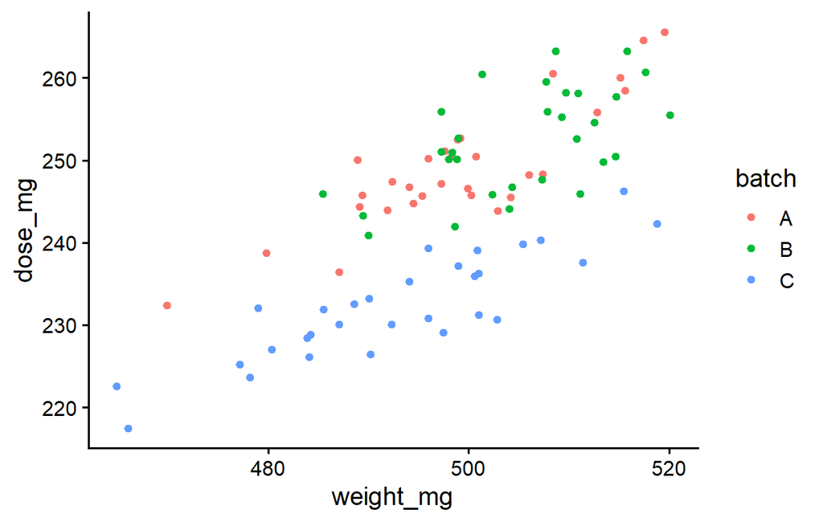

```r
p_batch
```

## 13.3 Export with `ggsave()`

| Argument | What it does |
| --- | --- |
| `"name.png"` | file name; the extension sets the type: `.png`, `.pdf`, `.svg`, `.jpg` |
| `plot = p` | which plot; without it, the last plot you made |
| `width`, `height`, `units` | size, with `units = "cm"`, `"mm"` or `"in"` |
| `dpi = 300` | resolution for PNG/JPG (300 for print) |

```r
ggsave("dose_plot.png", plot = p_batch, width = 16, height = 10, units = "cm", dpi = 300)
ggsave("dose_plot.svg", plot = p_batch, width = 16, height = 10, units = "cm")
```

**SVG** is a vector format: sharp at any size, and you can open it in [Inkscape](https://inkscape.org) (free) to change text or move elements. Use this only for final touches: changes are lost when the code runs again. `ggsave()` needs the svglite package to save .svg files. If R says it is missing, run `install.packages("svglite")` once.

# 14 Where to go next

Two packages built on ggplot2, with other ways to make plots and statistical comparisons:

- **ggpubr** ([rpkgs.datanovia.com/ggpubr](https://rpkgs.datanovia.com/ggpubr/)): ready-made publication plots and p-values on plots. We used it in Code Club 4 (`ggboxplot()` + `stat_compare_means()`).
- **tidyplots** (tidyplots.org): build a plot step by step with the pipe.

`study` is a small example dataset that comes with tidyplots, so the code below runs once the package is installed.

```r
# install.packages("tidyplots")   # run once (remove the # first)
library(tidyplots)
study %>%
  tidyplot(x = treatment, y = score, color = treatment) %>%
  add_boxplot() %>%
  add_test_pvalue(ref.group = 1)
```

Both are built on ggplot2. In ggpubr you can add layers and themes with `+` as usual; in tidyplots you add ggplot2 code with `add()`, e.g. `add(theme_bw())`.